# Effects of Climate Change on Estuarine Fish Assemblages

Author

Affiliation

Garrett Miller

The University of South Florida

Abstract

This is a test abstract

# Introduction

Global climate change is having strong effects on biodiversity and associated ecosystem structure and functions (Doney et al. 2012, Poloczanska et al. 2016, Murphy et al. 2020). Shifts in species distributions (McCarty 2001), changes in phenology (Stenseth and Mysterud 2002), and changes in biodiversity (Dornelas et al. 2019) have been observed globally. However, the direction and magnitude of change varies. For example, species richness is declining around the equator and increasing at midlatitudes (Chaudhary et al. 2021). Some taxa are migrating poleward while others remain unchanged in distribution (Parmesan et al. 1999, Perry et al. 2005, Chivers et al. 2017). Given that changes in biodiversity can affect ecosystem stability (Hautier et al. 2015), there has been increased concern about how climate change will alter ecosystems, including rainforests (Levine et al. 2016), coral reefs (Toth et al. 2019), and estuaries (Erickson et al. 2021). However, our understanding of changes in ecosystem stability has been limited by a paucity of long-term time series data (but see Dornelas et al. 2018). Further, many ecosystems at lower latitudes have received comparatively less attention than those at higher latitudes. Understanding stability in these lower latitude ecosystems can shed light on their responses to climate change and broaden our understanding about generalities.

Temperature is known to affect population-level demographics in several ways, including the sex ratio of offspring (Ospina-Álvarez and Piferrer 2008), growth rates of young (Raventos et al. 2021), and individual survivorship (Stevens et al. 2016). However, the effects of shifting temperatures are more nuanced at the community level. Studies have highlighted such influences as changes in seasonal weather extremes (Easterling et al. 2000, Miner et al. 2021), shifts in season duration (Cooper 2014), and variation in disturbance frequency, intensity, and duration (Dale et al. 2001), among others. Such factors can drive community-level change in different magnitudes and directions. For example, as distributions of taxa shift in response to warming temperature, the invasion of predators and new pathogens can lead to the extirpation of native species (Sax et al. 2007). Although average temperatures are increasing globally, the magnitude of these changes may not be consistent among seasons, with warming expected to occur more quickly in the winter than the summer for many ecosystems (Clark et al. 2020). This seasonal imbalance in temperature change has already contributed to the global poleward expansion of mangroves and is linked to a reduction in frequency and intensity of cold weather events (Saintilan et al. 2014). Given the importance of season on biota globally, such asymmetric change in temperature may have complex effects. For example, the intensity of a preceding winter is associated with the structure of estuarine fish assemblages the following spring (Curran and Wilber 2019). In addition, the concurrent increase in temperature variability due to climate change has been demonstrated to directly influence species richness and community stability (Zhang et al. 2018). Within marine systems, there is evidence that regions at lower latitude have become less stable compared to their higher latitude counterparts due to their responses to temperature (Miner et al. 2021).

The eastern Gulf of Mexico (eGOM) is a productive subtropical region that supports diverse communities including mangrove- and salt marsh-dominated estuaries, seagrass systems, and hardbottom reefs. The region is bisected by the Northern Gulf of Mexico ecoregion to the north and Floridian to the south, which are characterized by compositionally different marine assemblages (Spalding et al. 2007). Seagrass systems throughout the eGOM act as important juvenile habitats for many fishes and exhibit high regional variability in the populations and communities they support (Schrandt et al. 2018, Faletti et al. 2019, Peake et al. 2022). Globally, temperate ecosystems are undergoing tropicalization, with previously rare or absent tropically-associated taxa increasing in abundance through time (Nakamura et al. 2013, Osland et al. 2021). The effects of these new taxa are profound and can lead to regime shifts (Vergés et al. 2014, Wernberg et al. 2016). Yet, there is evidence that some subtropical ecosystems are resilient to tropicalization due to additional factors, such as dispersal limitations of new taxa (Mizerek et al. 2021). In the eGOM, a reduced frequency of extreme cold events has been linked to the expansion of three co-occurring mangrove species in Florida estuaries (Cavanaugh et al. 2014). This is already creating novel mangrove-marsh assemblages (Cook-Patton et al. 2015) and shifts in faunal communities are predicted to follow (Scheffel et al. 2018). Indeed, warmer winter temperatures have been associated with the poleward expansion of a mangrove-associated fish species in this region (Purtlebaugh et al. 2020) and has affected community stability in other estuarine systems in North America (Miner et al. 2021).

Increased abundance of tropically-associated taxa had already been observed in northern Gulf of Mexico seagrass systems as early as 2006, potentially indicating tropicalization by taxa from the Floridian ecoregion (Fodrie et al. 2010). However, Fodrie et al. (2010) was restricted to the northernmost edge of the eGOM as well as only the summer and fall seasons. Further, assemblages commonly differ between summer and winter in subtropical and temperate estuaries (Hagan and Able 2003, Strydom 2015, Schrandt and MacDonald 2020). Thus, it is unclear how estuarine systems across the broader eGOM may be responding to climate change, especially in the context of imbalanced changes in average seasonal temperatures. Long-term data collected consistently within and across multiple eGOM estuaries that span temperate and subtropical latitudes can improve our ability to evaluate the stability of these assemblages and establish a timeline of tropicalization in this region. Long-term time series data are available in the eGOM, where estuarine fish composition and abundance surveys have been conducted monthly since 1997 and followed consistent study designs and methods. Using these data, I investigated whether fish assemblages in estuaries within the eGOM changed over a 23-year period and if there was a potential response to climate change. Specifically, I addressed the following questions: 1) Has water temperature and submerged aquatic vegetation coverage changed in eGOM estuaries over a 23-year period? 2) Has the richness and abundance of fishes within eGOM estuarine fish assemblages changed over this same time period and, if so, are these changes related to water temperature? 3) Has the composition and stability of eGOM estuarine fish assemblages changed over time?

# Methods

## Data Collection

This study used data collected by the Florida Fish and Wildlife Research Institute’s (FWRI) Fisheries Independent Monitoring (FIM) program. The program follows a monthly stratified random sampling design in estuaries across Florida, including four in the eastern Gulf of Mexico (from north to south: Apalachicola Bay (AB), Cedar Key (CK), Tampa Bay (TB), and Charlotte Harbor (CH); Figure 1). Apalachicola Bay is a shallow, semi-enclosed estuary located on the northern coast of the GOM in the panhandle of Florida, USA and is within the Northern Gulf of Mexico ecoregion (Spalding et al. 2007). Cedar Key is located within the Suwannee River open estuary system and is also in the Northern Gulf of Mexico ecoregion. Tampa Bay is Florida’s largest open water estuary and lies within the Floridian ecoregion (Spalding et al. 2007). Charlotte Harbor, a drowned river estuary system, is within the Floridian ecoregion (FWRI 2017). All systems are dominated by seagrass vegetation in shallow waters, except for Apalachicola Bay, where seagrass is less than 7% of bottom coverage (FWRI 2017). However, sampling gear was partly determined by habitat, where all seagrass at particular depths were sampled with the same gear type across estuaries [≤1.8-m deep; see also below, FWRI (2017)]. Finally, salt marsh and oyster beds are dominant along shorelines in Apalachicola Bay and Cedar Key, while mangroves dominate in Charlotte Harbor, and Tampa Bay is characterized by a mix of salt marsh, oyster beds, and mangroves (FWRI 2017).

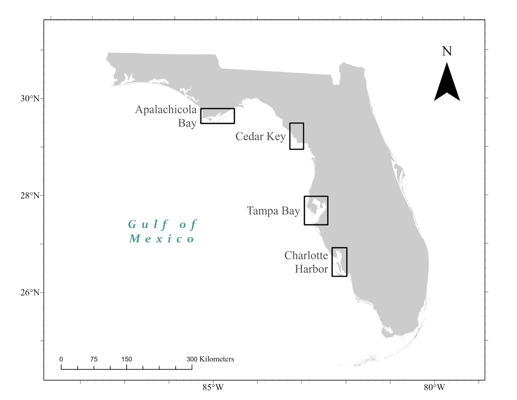

Figure 1: Locations of all estuarine systems in this study.

Sampling was divided into zones (subdivided into 1-nm<sup>2</sup> grids) within each estuarine system based on geographic, habitat, and depth criteria (FWRI 2017). These criteria defined which of three different types of gear were used to collect organisms. For this study, I used data from the 21.3-m seine sampling gear because it was used the longest and most consistently throughout the study period. Specifically, this gear targeted young-of-year and juvenile fishes in shallow habitats (≤1.8-m deep). For every seine haul (hereafter referred to as “sampling event”), all vertebrates and select commercially-important invertebrates were counted and identified to the lowest practical taxonomic level (typically species). I used all available summer and winter seine net data from 1998 to 2020. I filtered each sampling event by season, with summer defined as June-September and winter as December-March, following Schrandt and MacDonald (2020). To reduce potential effects of *in situ* species-level misidentification, I aggregated certain taxa to the genus level due to similarity in appearance (Table 1). A visual estimate of the submerged aquatic vegetation (SAV) coverage was recorded for each sampling event. Finally, a YSI sonde was used to record water temperature at the surface of the water and the bottom during each sampling event. For my analyses, I calculated the average of the two water temperature values to produce a mean water column temperature for each sampling event.

In total, 17,492 sampling events occurred where at least one taxon was caught and counted during summer and winter in any of the four systems. For seven sampling events, water temperature data were unavailable and thus excluded from the analyses. Further, I removed hauls composed solely of rare species (taxa found in ≤5% of all samples for that system and season) from the analyses which reduced the sample count to 17,260. Overall, the dataset contained 297 taxa recorded over 23 years of collections.

Table 1: Taxa that were difficult to identify in the field and subsequently aggregated at the genus level to reduce misidentification effects.

| Genus | Species |
| --- | --- |
| Anchoa | A. cayorum |
|  | A. cubana |
|  | A. hepsetus |
|  | A. lamprotaenia |
|  | A. lyolepis |
|  | A. mitchilli |
| Eucinostomus | E. argenteus |
|  | E. gula |
|  | E. harengulus |
|  | E. havana |
|  | E. jonesii |
|  | E. lefroyi |
|  | E. melanopterus |
| Farfantepenaeus | F. aztecus |
|  | F. duorarum |

## Data Analyses

I conducted all analyses using the R Statistical Computing Environment v4.3.0 with an alpha of 0.05 for all significance testing (R Core Team 2023). Unless otherwise indicated, I reported values from all analyses as mean ± SE and generated plots with R packages *ggplot2* and *patchwork* (Wickham 2016, Pedersen 2022). To address if SAV coverage and water temperature have changed over time in eGOM estuarine systems, I used Analysis of Covariance (ANCOVA) models, with Year as a continuous predictor (fixed) and estuarine System as a categorical predictor (fixed, 4 levels: Apalachicola Bay, Cedar Key, Tampa Bay, Charlotte Harbor) plus their interaction. Given the well-documented seasonal differences in estuarine systems (see Hagan and Able 2003, Strydom 2015, Schrandt and MacDonald 2020), in this and all subsequent analyses, I separately analyzed summer and winter. The formula used for each ANCOVA was:

```r
response ~ Year + System + Year:System
```

where response was either mean annual percent SAV coverage or mean annual water temperature. When the interaction between Year and System was not significant, I dropped the term and reran the test as an additive model. For significant interactions between Year and System, I ran independent linear models by Year for each system within each season. Prior to this analysis, I removed any outlier data from years in which temperatures were anomalously higher or lower (>2.5 standard deviations) than the long-term average (e.g., winter of 2010). I performed post-hoc contrasts for any significant terms in these models to determine the magnitude of differences in means across systems using the *emmeans* package and used the Tukey method for *p*-value correction (Lenth 2023).

To test whether the richness and abundance of fishes from the focal estuaries changed over the study period and assess the effects of water temperature on these assemblages, I modeled total richness and total abundance per sampling event across all systems for both the summer and winter seasons using generalized linear mixed models (GLMMs) from the R package *glmmTMB* (Brooks et al. 2017). For each sampling event, I calculated the richness as the number of distinct taxa present and total abundance as the sum of all enumerated individuals. In this and all subsequent analyses, I fourth-root transformed the abundance data prior to summation to reduce the effects of overly abundant taxa. For each model, the predictors were Year (fixed, continuous), System (fixed, categorical with 4 levels: Apalachicola Bay, Cedar Key, Tampa Bay, Charlotte Harbor), Water Temperature (fixed, continuous), and SAV Coverage (fixed, continuous) as predictors. I also included an interaction term between Year and System and treated it the same as in the above-described models. I applied a z-score transformation to SAV Coverage and Water Temperature to enable comparison of relative effect sizes. Since sampling events were conducted in consecutive months, I included a first-order autoregressive covariance term in each model based on sampling month to account for temporal autocorrelation (Brooks et al. 2017). This covariance term included within-system zone as a random grouping effect to further address spatial autocorrelation . Given that species richness is strongly affected by sampling effort (Mittelbach and McGill 2019), I included an offset term to account for variation in the number of sampling events. Thus, I used the following formula for each model:

```r
response ~ Year + System + Year:System + Temp_Z + SAV_Z + offset(log(n_hauls)) + ar1(yearMonth + 0|systemZone)
```

where `response` was either total richness or fourth-root transformed total abundance per haul. I again used the *emmeans* package for post-hoc contrasts of means and the Tukey method for *p*-value correction (Lenth 2023).

To examine the composition and stability of eGOM estuarine fish assemblages over time, I started with a univariate approach examining beta diversity with Bray-Curtis dissimilarity over time. I first calculated the mean annual abundance of each taxon for each system within each season. I used the R package *betapart* to then calculate Bray-Curtis dissimilarity annually with respect to the first year of available data (Baselga et al. 2023). I modeled this dissimilarity index over time with ANCOVA using the formula:

```r
beta diversity index ~ Year + System + Year:System
```

I treated the interaction term the same as described above. I then used permutational multivariate analysis of variance (PERMANOVA) from the R package *vegan* to evaluate the effect of Year (fixed, categorical) and System (fixed, four levels), plus their interaction, within season on square-root transformed Bray-Curtis dissimilarities of the fourth-root transformed assemblage data (Oksanen et al. 2022). I used square-root transformed Bray-Curtis dissimilarity matrices to provide a more conservative estimate of the variance explained by the subsequent PERMANOVAs (Legendre and Andersson 1999). The resultant models used were thus:

```r
(Bray-Curtis matrix)^0.5 ~ Year + System + Year:System
```

I handled the interaction term in the same manner as described above. I generated canonical analysis of principal coordinates (CAP) ordinations using the R package *BiodiversityR* to visualize patterns across Years for any PERMANOVAs that indicated a significant effect of Year within each System and season (Kindt and Coe 2005, *sensu* Peake et al. 2022). In addition, I included taxon biplot correlation vectors in these CAP ordinations to visualize which taxa contributed to any observed differences in groups. I applied the Pythagorean theorem to the first two axis scores of each taxon vector to evaluate its relative magnitude. To explore the effects of SAV coverage and water temperature on the assemblages, I performed distance-based redundancy analysis (dbRDA) with the R package *vegan* using the same square-root transformed Bray-Curtis dissimilarities stated above (Oksanen et al. 2022). The resultant formula was thus:

```r
(Bray-Curtis matrix)^0.5 ~ Year + Temp_Z + SAV_Z
```

Finally, I followed methods described in Dornelas et al. (2019) to assess whether the abundance of individual taxa had changed over time. Within each system and season, I ran a linear model on the average annual fourth-root transformed abundance for each taxon against time to calculate both the magnitude and direction of change. I binned the model coefficients to construct histograms that displayed the distribution and magnitude of rates of change for each system within season. I then assessed the balance of how many taxa increased or decreased significantly in abundance for each system within season. Finally, I pulled climatological association data from FishBase using the R package *rfishbase* and examined whether there were patterns in the climatological associations of any taxa that underwent significant change (Boettiger et al. 2012).

# Results

## Overview

Throughout the 23-year study period, submerged aquatic vegetation (SAV) displayed nuanced dynamics, with no observed change in Apalachicola Bay for either season, a decrease in Cedar Key during summer only, an increase in Tampa Bay during winter only, and increases observed in Charlotte Harbor (both seasons; Figure 2). Water temperature increased during summer and winter for all estuary systems, but the rate in winter was more than triple that observed during the summer (Figure 3). Of the 297 total taxa examined, 89 (30%) changed significantly in abundance over time across all systems, nearly equally balanced between increases and decreases in abundances.

## Habitat Dynamics

### Submerged Aquatic Vegetation

Table 2: Slopes of SAV change over time for all independent linear models. Bold rows highlight terms where *p* <0.05.

| Season | System | Slope | Standard error | t-statistic | p-value |
| --- | --- | --- | --- | --- | --- |
| Summer | AB | 0.235 | 0.146 | 1.61 | 0.126 |
|  | CK | -0.441 | 0.146 | -3.02 | 0.007 |
|  | TB | 0.065 | 0.098 | 0.66 | 0.518 |
|  | CH | 0.348 | 0.118 | 2.96 | 0.008 |
| Winter | AB | -0.155 | 0.171 | -0.91 | 0.377 |
|  | CK | -0.209 | 0.124 | -1.68 | 0.110 |
|  | TB | 0.404 | 0.101 | 4.01 | <0.001 |
|  | CH | 0.486 | 0.117 | 4.17 | <0.001 |

Table 3: Least square means of SAV in each system for both seasonal linear models.

| Season | System | Estimated mean | Standard error | df |
| --- | --- | --- | --- | --- |
| Summer | AB | 32.0 | 0.81 | 78 |
|  | CK | 13.6 | 0.81 | 78 |
|  | TB | 39.5 | 0.76 | 78 |
|  | CH | 49.7 | 0.76 | 78 |
| Winter | AB | 26.5 | 0.83 | 78 |
|  | CK | 9.2 | 0.83 | 78 |
|  | TB | 41.2 | 0.77 | 78 |
|  | CH | 46.4 | 0.77 | 78 |

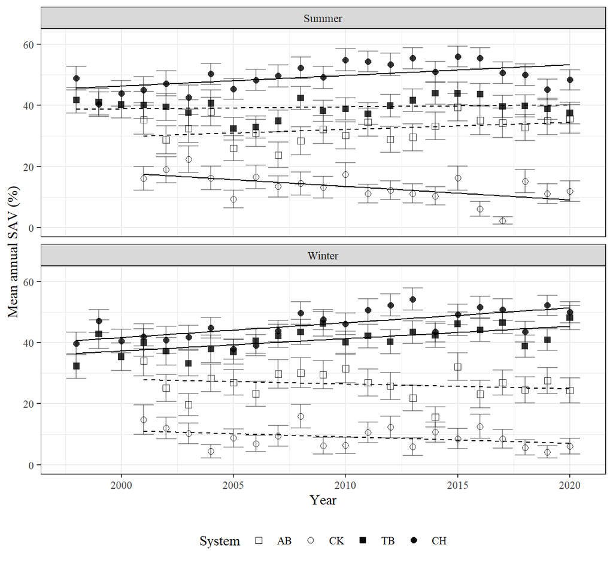

Figure 2: Annually averaged SAV coverage over time. Error bars represent ± 1 standard error. Solid lines indicate significant modeled trends and dashed lines indicate non-significant trends, per each independent linear model.

### Water Temperature

During the 23-year study period, water temperature increased consistently across all systems (Year:System interaction term for summer *p* = 0.627 and winter *p* = 0.917). Summer water temperature increased at a rate of 0.018°Cyr<sup>-1</sup> ± 0.007 and winter water temperature increased more than three times as quickly at a rate of 0.063°Cyr<sup>-1</sup> ± 0.015 (Figure 3). Despite the consistency in the rates of increase, post-hoc contrasts revealed the long-term mean water temperatures differed among most systems, with Charlotte Harbor consistently warmer than all other estuaries in both seasons (*p* <0.05 for 9 out of 12 pairwise comparisons; Table 4).

Table 4: Least square means of water temperature in each system for both seasonal linear models.

| Season | System | Estimated mean | Standard error | df |
| --- | --- | --- | --- | --- |
| Summer | AB | 29.6 | 0.09 | 81 |
|  | CK | 29.3 | 0.09 | 81 |
|  | TB | 29.8 | 0.08 | 81 |
|  | CH | 30.2 | 0.08 | 81 |
| Winter | AB | 15.9 | 0.21 | 77 |
|  | CK | 16.4 | 0.21 | 77 |
|  | TB | 19.2 | 0.19 | 77 |
|  | CH | 20.9 | 0.19 | 77 |

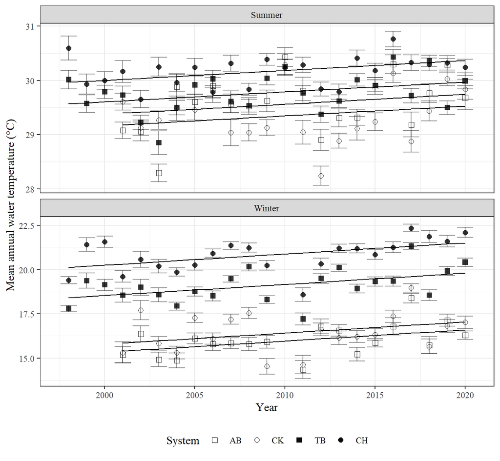

Figure 3: Annually averaged water temperature over time. Error bars represent ± 1 standard error. Slopes of lines are derived from ANCOVA models.

## Assemblage Structure: Patterns and Dynamics

### Abundance and Richness

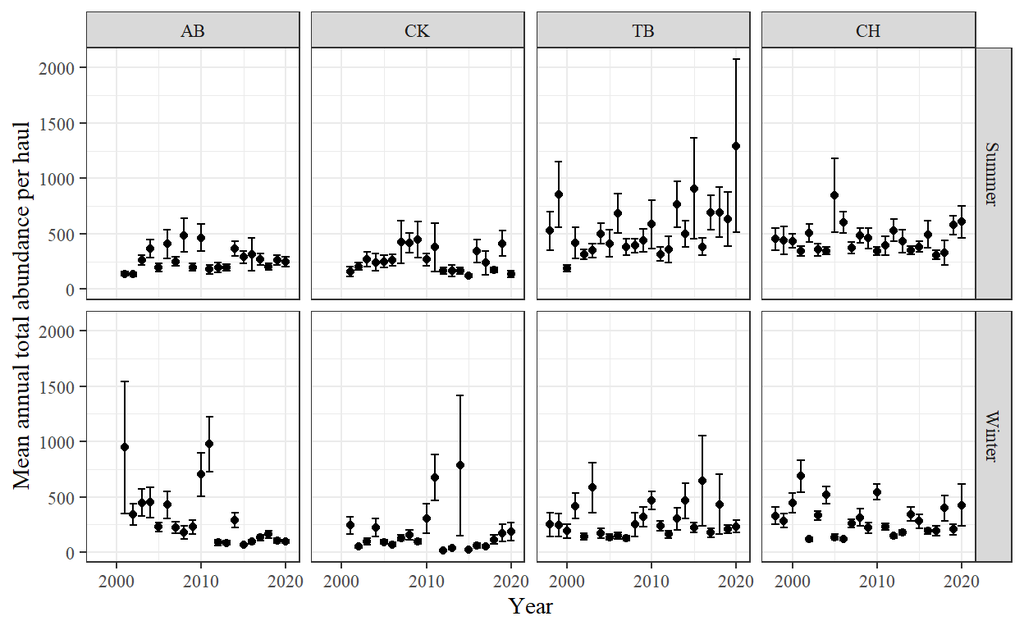

Figure 4: Mean total faunal abundance (fourth-root transformed) per haul over time. Error bars represent ± 1 standard error.

Table 5: Coefficients of terms in total faunal abundance GLMMs. Bold rows highlight terms where *p* <0.05.

| Season | System | Term | Coefficient | Standard error | t-statistic | p-value |
| --- | --- | --- | --- | --- | --- | --- |
| Summer | AB | Year | 1.108 | 4.828 | 0.23 | 0.819 |
|  |  | Temp_Z | -6.933 | 17.260 | -0.40 | 0.688 |
|  |  | SAV_Z | 91.130 | 16.396 | 5.56 | <0.001 |
|  | CK | Year | -2.228 | 3.723 | -0.60 | 0.550 |
|  |  | Temp_Z | -1.604 | 21.497 | -0.07 | 0.941 |
|  |  | SAV_Z | -33.589 | 21.557 | -1.56 | 0.119 |
|  | TB | Year | 18.257 | 8.199 | 2.23 | 0.026 |
|  |  | Temp_Z | -33.255 | 52.819 | -0.63 | 0.529 |
|  |  | SAV_Z | 132.835 | 52.679 | 2.52 | 0.012 |
|  | CH | Year | -0.933 | 3.695 | -0.25 | 0.801 |
|  |  | Temp_Z | -9.156 | 23.645 | -0.39 | 0.699 |
|  |  | SAV_Z | 72.756 | 23.644 | 3.08 | 0.002 |
| Winter | AB | Year | -26.851 | 5.836 | -4.60 | <0.001 |
|  |  | Temp_Z | 100.240 | 33.454 | 3.00 | 0.003 |
|  |  | SAV_Z | -73.846 | 33.167 | -2.23 | 0.026 |
|  | CK | Year | 2.370 | 6.542 | 0.36 | 0.717 |
|  |  | Temp_Z | -12.954 | 37.420 | -0.35 | 0.729 |
|  |  | SAV_Z | -27.792 | 37.361 | -0.74 | 0.457 |
|  | TB | Year | 1.811 | 4.588 | 0.39 | 0.693 |
|  |  | Temp_Z | 67.465 | 29.553 | 2.28 | 0.022 |
|  |  | SAV_Z | 79.617 | 29.342 | 2.71 | 0.007 |
|  | CH | Year | -6.225 | 3.546 | -1.76 | 0.079 |
|  |  | Temp_Z | 99.256 | 17.225 | 5.76 | <0.001 |
|  |  | SAV_Z | 83.063 | 16.404 | 5.06 | <0.001 |

Mean richness per haul in summer (8.7 ±0.046) was consistently higher for each system than in the winter (5.8 ±0.038; Figure 5). The Year:System interaction terms for the richness GLMMs were not significant in either seasonal model (*p* = 0.156 to 0.912), therefore, I used additive models for each system. The revised GLMMs revealed that richness did not change during either summer or winter for any system (summer *p* = 0.154 and winter *p* = 0.535; Table 6). Further, richness in summer was positively related to SAV coverage for all systems (*p* = <0.001; Table 6) and not related to water temperature (*p* = 0.092; Table 6). In contrast, richness in winter was positively related to both SAV coverage (*p* = <0.001; Table 6) and water temperature for all systems (*p* = <0.001; Table 6).

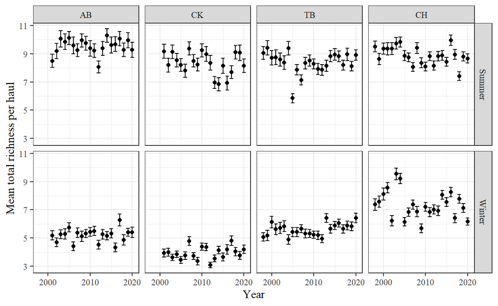

Figure 5: Mean total richness averaged annually. Error bars represent ± 1 standard error.

Table 6: Coefficients of terms in total faunal richness GLMMs. Bold rows highlight terms where *p* <0.05.

| Season | Term | Coefficient | Standard error | t-statistic | p-value |
| --- | --- | --- | --- | --- | --- |
| Summer | (Intercept) | 2.364 | 0.302 | 7.84 | <0.001 |
|  | Year | -0.020 | 0.014 | -1.42 | 0.154 |
|  | systemCK | -1.188 | 0.343 | -3.47 | <0.001 |
|  | systemTB | -1.706 | 0.287 | -5.94 | <0.001 |
|  | systemCH | -1.262 | 0.296 | -4.27 | <0.001 |
|  | SAV_Z | 1.497 | 0.045 | 33.60 | <0.001 |
|  | Temp_Z | 0.075 | 0.045 | 1.69 | 0.092 |
| Winter | (Intercept) | -2.056 | 0.325 | -6.32 | <0.001 |
|  | Year | -0.009 | 0.015 | -0.62 | 0.535 |
|  | systemCK | -1.161 | 0.377 | -3.08 | 0.002 |
|  | systemTB | -0.072 | 0.313 | -0.23 | 0.818 |
|  | systemCH | 1.555 | 0.323 | 4.81 | <0.001 |
|  | SAV_Z | 0.657 | 0.036 | 18.27 | <0.001 |
|  | Temp_Z | 0.469 | 0.037 | 12.80 | <0.001 |

### Beta Diversity

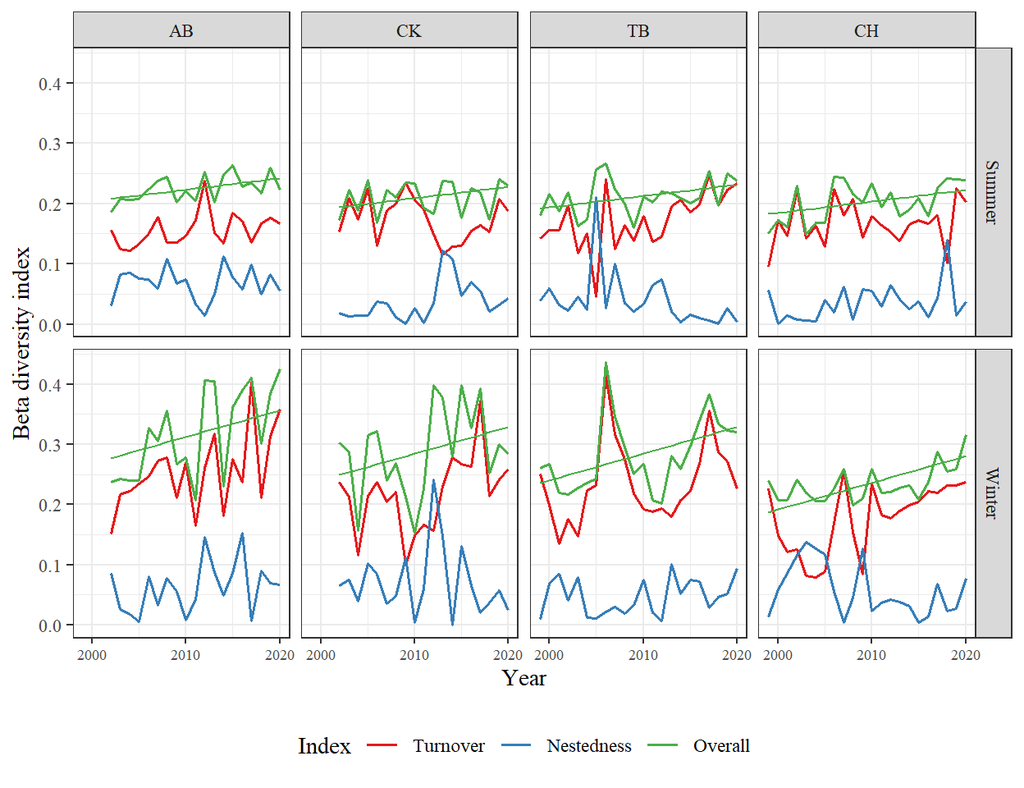

Figure 6: Partitioned beta diversity calculated pairwise with respect to the first year of available data. Trend lines calculated using seasonal ANCOVA models.

Bray-Curtis dissimilarity of species composition increased consistently across all systems within each season (Year:System interaction term for summer *p* = 0.592 and winter *p* = 0.232). The rate of increase in dissimilarity during summer was 0.002yr<sup>-1</sup> ± 5e-04, with winter increasing at twice the summer rate (0.004yr<sup>-1</sup> ± 0.001; Table 7; Figure 6). In summer, the variability of dissimilarity was lower than in the winter for all systems except Charlotte Harbor (Table 8). Within dissimilarity overall, there were clear variations in the underlying components of beta diversity (turnover and nestedness), though they were not modeled here.

Table 7: ANCOVA model outputs for betadiversity indices over time. Bold values are statistically significant at alpha 0.05.

| Season | Term | Estimate | Standard error | t-statistic | p-value |
| --- | --- | --- | --- | --- | --- |
| Summer | (Intercept) | 0.202 | 0.008 | 24.76 | <0.001 |
|  | Year | 0.002 | 0.000 | 3.98 | <0.001 |
|  | systemCK | -0.014 | 0.008 | -1.68 | 0.096 |
|  | systemTB | -0.010 | 0.008 | -1.30 | 0.197 |
|  | systemCH | -0.020 | 0.008 | -2.44 | 0.017 |
| Winter | (Intercept) | 0.263 | 0.018 | 15.03 | <0.001 |
|  | Year | 0.004 | 0.001 | 4.36 | <0.001 |
|  | systemCK | -0.028 | 0.018 | -1.55 | 0.125 |
|  | systemTB | -0.028 | 0.017 | -1.60 | 0.113 |
|  | systemCH | -0.076 | 0.017 | -4.42 | <0.001 |

Table 8: Coefficients of variation in the Bray-Curtis dissimilarity index for each season and system.

| Season | System | Coefficient of Variation |
| --- | --- | --- |
| Summer | AP | 9.62 |
|  | CK | 12.41 |
|  | TB | 13.71 |
|  | CH | 16.08 |
| Winter | AP | 23.24 |
|  | CK | 25.31 |
|  | TB | 21.44 |
|  | CH | 12.55 |

PERMANOVAs indicated assemblage composition and abundance varied differently over time among systems (Year:System interaction term for summer *p* = 0.001 and winter *p* = 0.001; Table 9). I therefore conducted separate PEMANOVAs and CAP ordinations for each system within each season (*sensu* Peake et al. 2022). From the individual PERMANOVA models, assemblage composition changed significantly over time in each estuary and each season (all *p* = 0.001; Table 10).

Table 9: Summary outputs from assemblage composition and abundance PERMANOVAs conducted for each season. Values in bold are statistically significant at alpha 0.05.

| Season | Term | Df | Sum of squares | R2 | Statistic | p-value |
| --- | --- | --- | --- | --- | --- | --- |
| Summer | Year | 22 | 13.80 | 0.01 | 5.08 | 0.001 |
|  | System | 3 | 48.23 | 0.04 | 130.29 | 0.001 |
|  | Year:System | 60 | 16.59 | 0.01 | 2.24 | 0.001 |
|  | Residual | 8,833 | 1,089.98 | 0.93 |  |  |
|  | Total | 8,918 | 1,168.61 | 1.00 |  |  |
| Winter | Year | 22 | 60.07 | 0.02 | 6.99 | 0.001 |
|  | System | 3 | 159.80 | 0.05 | 136.32 | 0.001 |
|  | Year:System | 60 | 58.32 | 0.02 | 2.49 | 0.001 |
|  | Residual | 8,255 | 3,225.64 | 0.92 |  |  |
|  | Total | 8,340 | 3,503.83 | 1.00 |  |  |

Table 10: Outputs from assemblage composition and abundance PERMANOVAs conducted for each system and season combination. Values in bold are statistically significant at alpha 0.05.

| Season | System | Term | Df | Sum of squares | R2 | F | p-value |
| --- | --- | --- | --- | --- | --- | --- | --- |
| Summer | AB | Year | 19 | 13.94 | 0.02 | 1.91 | 0.001 |
|  |  | Residual | 1,563 | 600.52 | 0.98 |  |  |
|  |  | Total | 1,582 | 614.47 | 1.00 |  |  |
|  | CK | Year | 19 | 16.41 | 0.03 | 2.22 | 0.001 |
|  |  | Residual | 1,625 | 632.01 | 0.97 |  |  |
|  |  | Total | 1,644 | 648.42 | 1.00 |  |  |
|  | TB | Year | 22 | 21.57 | 0.02 | 2.58 | 0.001 |
|  |  | Residual | 2,796 | 1,064.60 | 0.98 |  |  |
|  |  | Total | 2,818 | 1,086.17 | 1.00 |  |  |
|  | CH | Year | 22 | 24.18 | 0.02 | 3.29 | 0.001 |
|  |  | Residual | 2,849 | 950.80 | 0.98 |  |  |
|  |  | Total | 2,871 | 974.98 | 1.00 |  |  |
| Winter | AB | Year | 19 | 20.87 | 0.04 | 2.89 | 0.001 |
|  |  | Residual | 1,428 | 542.04 | 0.96 |  |  |
|  |  | Total | 1,447 | 562.91 | 1.00 |  |  |
|  | CK | Year | 19 | 19.94 | 0.03 | 2.65 | 0.001 |
|  |  | Residual | 1,427 | 565.59 | 0.97 |  |  |
|  |  | Total | 1,446 | 585.52 | 1.00 |  |  |
|  | TB | Year | 22 | 33.83 | 0.03 | 3.72 | 0.001 |
|  |  | Residual | 2,621 | 1,084.62 | 0.97 |  |  |
|  |  | Total | 2,643 | 1,118.46 | 1.00 |  |  |
|  | CH | Year | 22 | 39.56 | 0.04 | 4.84 | 0.001 |
|  |  | Residual | 2,779 | 1,033.39 | 0.96 |  |  |
|  |  | Total | 2,801 | 1,072.95 | 1.00 |  |  |

Table 11: Taxon with the greatest magnitude vector as measured on the first two axes of variation for each system and season.

| Season | System | Scientific name |
| --- | --- | --- |
| Summer | AB | Microgobius thalassinus |
|  | CK | Eucinostomus spp. |
|  | TB | Eucinostomus spp. |
|  | CH | Lagodon rhomboides |
| Winter | AB | Leiostomus xanthurus |
|  | CK | Leiostomus xanthurus |
|  | TB | Leiostomus xanthurus |
|  | CH | Leiostomus xanthurus |

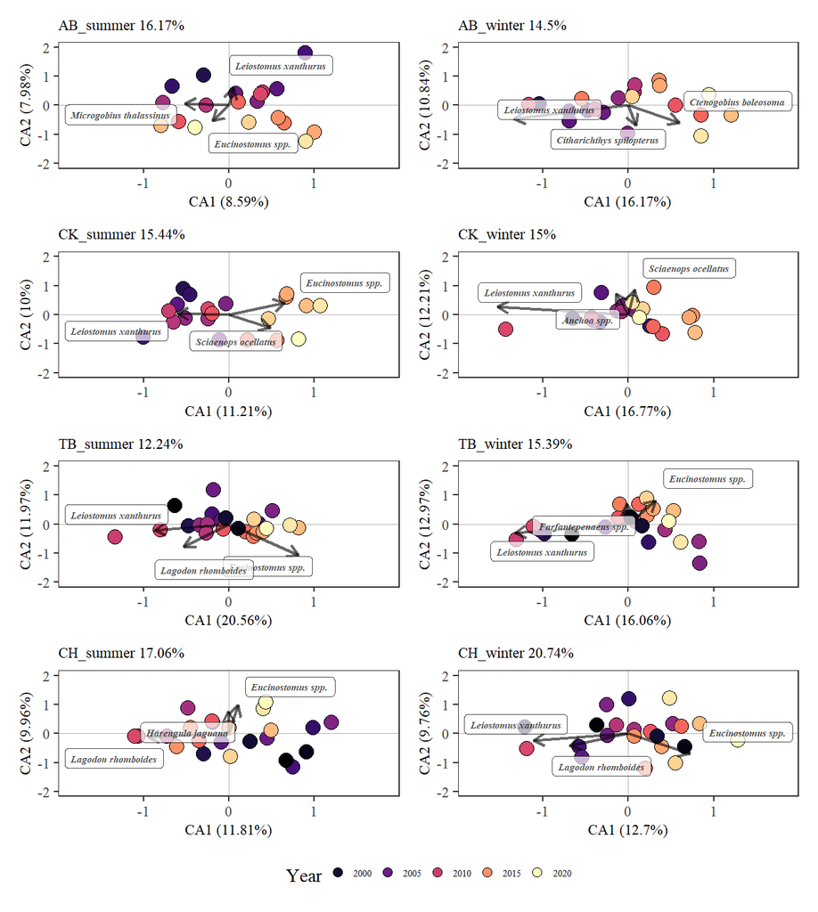

Figure 7: Canonical analysis of principal coordinates ordinations of assemblage composition and abundance. Shading of markers indicates year for that group, with darker colors indicating centroids of the oldest years in the data and lighter colors indicating the most recent years. Percentages next to subplot title indicate total variability captured by the model. Top three taxa associated with canonical axes scores plotted as vectors. Canonical axis (CA) percentages indicate the among-group variation captured in each axis.

SAV and water temperature were significantly related to beta diversity across all systems and seasons (Figure 8). However, there were no clear temporal patterns in most of the ordinations (Figure 8). Across systems, Tampa Bay had the most tightly clustered group of yearly centroids, particularly in winter (Figure 8). In all systems, both SAV coverage and water temperature had strong correlations with the first canonical axis as indicated by their direction and magnitude. Further, the relative magnitude of SAV coverage was generally greater than water temperature in all cases, suggesting a stronger influence on assemblage variability among years.

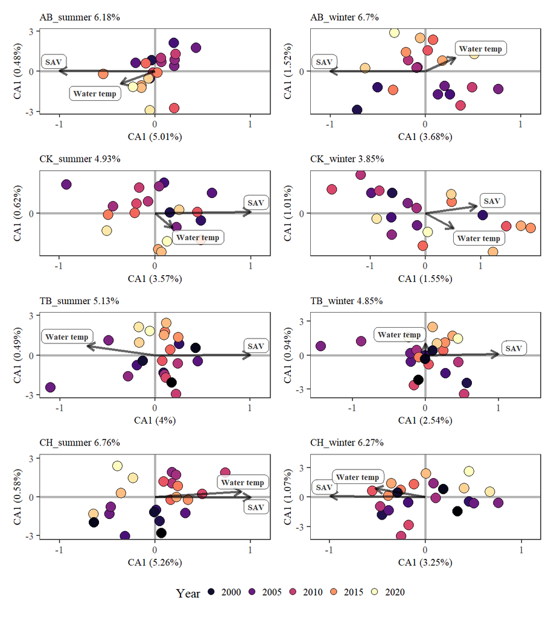

Figure 8: Distance-based redundancy analysis (dbRDA) ordination to visualize effects of habitat parameters. Shading of markers indicates year for that group, with darker colors indicating centroids of the oldest years in the data and lighter colors indicating the most recent years. Canonical axis (CA) percentages indicate the total variation in estuarine communities explained by that axis. Each habitat variable is represented by vectors and centroids of taxa groups are calculated using weighted average scores.

### Individual Taxon Analyses

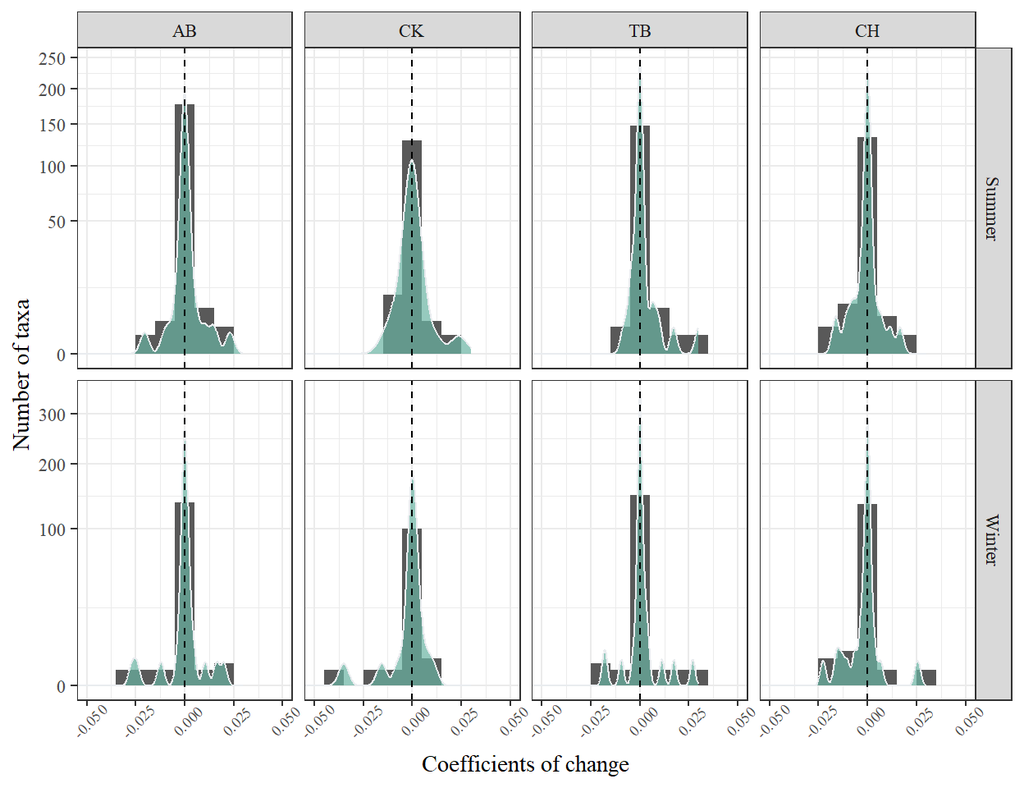

Figure 9: Density plots of slopes of all mean annual taxa abundances over time. Dashed line indicates a slope of 0. Includes slopes of no statistical significance.

The majority of taxa (70%) did not exhibit significant changes in abundance over time (208 out of 297 taxa), with a large group centered around zero rate of abundance change in both summer and winter for all systems (Figure 9). There was no difference in overall percentage of taxa changing between systems (*t* = 1.00; *p* = 0.479) or seasons (*t* = 1.27; *p* = 0.253). However, the percentage of taxa undergoing population declines was greater in the summer than in the winter (*t* = 2.59; *p* = 0.021; Table 12), with no difference between seasons in the percentage of taxa changing positively (*t* = -1.34; *p* = 0.884; Table 12).

Table 12: Percent of observed taxa with statistically significant changes in abundance over time as well as the split between positive and negative change within.

| Season | System | Change overall | Positive change | Negative change |
| --- | --- | --- | --- | --- |
| Summer | AB | 9.5% | 50.0% | 50.0% |
|  | CK | 16.1% | 43.5% | 56.5% |
|  | TB | 15.2% | 50.0% | 50.0% |
|  | CH | 17.0% | 48.0% | 52.0% |
| Winter | AB | 11.9% | 70.6% | 29.4% |
|  | CK | 8.5% | 77.8% | 22.2% |
|  | TB | 11.0% | 82.4% | 17.6% |
|  | CH | 15.3% | 54.5% | 45.5% |

Overall, most taxa that had significant changes in abundance were either tropical-associated or ubiquitous in distribution and experienced rather modest changes, yet, a few taxa had rates of change an order of magnitude greater than the rest (Table 13; Figure 10).

Table 13: Climatological associations of taxa that significantly changed over time. Percentages listed are calculated with respect to number of taxa with available climate data.

| Season | System | Climatology | Positive change | Negative change |
| --- | --- | --- | --- | --- |
| Summer | AB | Tropical | 27.3% | 9.1% |
|  |  | Ubiquitous | 18.2% | 45.5% |
|  | CK | Ubiquitous | 35.7% | 64.3% |
|  | TB | Tropical | 14.3% | 23.8% |
|  |  | Ubiquitous | 33.3% | 28.6% |
|  | CH | Tropical | 20.0% | 15.0% |
|  |  | Ubiquitous | 25.0% | 40.0% |
| Winter | AB | Tropical | 33.3% | 8.3% |
|  |  | Ubiquitous | 25.0% | 16.7% |
|  |  | Subtropical | 8.3% | 0.0% |
|  |  | Temperate | 8.3% | 0.0% |
|  | CK | Tropical | 16.7% | 0.0% |
|  |  | Ubiquitous | 66.7% | 16.7% |
|  | TB | Tropical | 33.3% | 8.3% |
|  |  | Ubiquitous | 58.3% | 0.0% |
|  | CH | Tropical | 28.6% | 21.4% |
|  |  | Ubiquitous | 28.6% | 21.4% |

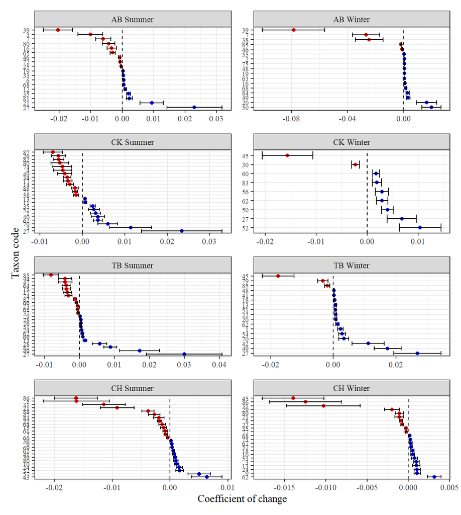